# Pi Measuring (Session 2)

Author

Takari Primary School, Year 4/5

Published

June 8, 2023

# Results

## Tables

We can report all of our observations in one big table but it isn’t very convenient to read or see any patterns!

All Observations

| Group | Object | Diameter (cm) | Circumference (cm) | Difficulty (1 to 10) |
| --- | --- | --- | --- | --- |
| Group 11 | Baking Tin | 23.0 | 74.0 | 6 |
| Group 1 | Coin | 3.7 | 9.2 | 1 |
| Group 10 | Pink Plastic Cup | 5.0 | 20.0 | 3 |
| Group 2 | Compact Disc (CD) | 12.0 | 40.0 | 2 |
| Group 4 | Tin of Tuna | 7.0 | 12.0 | 2 |
| Group 13 | Butter Cookie Tin | 19.2 | 60.5 | 4 |
| Group 10 | Pink Plastic Plate | 16.0 | 53.0 | 5 |
| Group 11 | Pink Plastic Cup | 9.0 | 36.0 | 8 |
| Group 2 | Small Glass Jam Jar | 4.0 | 15.0 | 1 |
| Group 3 | Cork Placemat | 22.0 | 70.0 | 2 |
| Group 10 | Flying Disc | 13.0 | 23.0 | 8 |
| Group 9 | Flying Disc | 24.0 | 70.0 | 5 |
| Group 11 | Colander | 17.0 | 72.0 | 7 |
| Group 2 | Tin of Tuna | 6.6 | 21.5 | 1 |
| Group 12 | AA Battery | 1.5 | 5.0 | 10 |
| Group 6 | Petri Dish | 9.5 | 29.0 | 4 |
| Group 8 | Milk Bottle Lid | 1.3 | 3.8 | 5 |
| Group 10 | Coin | 3.0 | 8.0 | 8 |
| Group 7 | S-26 Baby Formula Tin | 12.9 | 40.3 | 5 |
| Group 3 | Small Glass Jam Jar | 4.0 | 14.0 | 1 |
| Group 13 | Tin of Corn | 8.4 | 24.7 | 5 |
| Group 2 | Petri Dish | 8.5 | 28.0 | 2 |
| Group 11 | Tin of Tuna | 6.0 | 22.0 | 3 |
| Group 1 | Coin | 3.7 | 9.2 | 1 |
| Group 9 | Pink Plastic Cup | 8.0 | 22.0 | 6 |
| Group 4 | Pink Plastic Bowl | 12.0 | 34.0 | 3 |
| Group 5 | Christmas Cookie Tin | 13.0 | 24.0 | 5 |
| Group 10 | Milk Bottle Lid | 0.4 | 1.3 | 1 |
| Group 2 | Coin | 2.4 | 8.3 | 3 |
| Group 6 | Cork Placemat | 23.3 | 71.0 | 5 |
| Group 2 | Christmas Cookie Tin | 13.0 | 43.6 | 2 |
| Group 9 | Tin of Corn | 8.0 | 24.0 | 2 |
| Group 12 | S-26 Baby Formula Tin | 13.0 | 40.0 | 3 |
| Group 11 | Pink Plastic Cup | 6.0 | 21.0 | 2 |
| Group 1 | Compact Disc (CD) | 11.5 | 36.9 | 5 |
| Group 2 | Tin of Corn | 7.5 | 23.4 | 1 |
| Group 10 | Tin of Tuna | 7.0 | 21.0 | 1 |
| Group 8 | Flying Disc | 25.0 | 75.0 | 6 |
| Group 9 | Coin | 2.9 | 12.0 | 5 |
| Group 5 | Pink Plastic Bowl | 12.0 | 35.0 | 3 |
| Group 11 | Yellow Plastic Jar Lid | 7.0 | 25.0 | 10 |
| Group 2 | Pink Plastic Cup | 7.9 | 2.3 | 1 |
| Group 10 | Milk Bottle Lid | 5.0 | 13.0 | 1 |
| Group 8 | AA Battery | 1.0 | 5.0 | 2 |
| Group 3 | Roll-on Sunscreen | 4.5 | 15.0 | 1 |
| Group 4 | Baking Tin | 7.4 | 2.6 | 4 |
| Group 2 | Pink Plastic Plate | 16.0 | 58.0 | 1 |
| Group 11 | Tin of Corn | 8.0 | 24.0 | 5 |
| Group 6 | Christmas Cookie Tin | 14.1 | 43.1 | 4 |
| Group 13 | Compact Disc (CD) | 13.0 | 38.0 | 10 |
| Group 4 | Pink Plastic Cup | 7.0 | 24.0 | 2 |
| Group 5 | S-26 Baby Formula Tin | 13.0 | 40.0 | 1 |
| Group 1 | Cork Placemat | 22.2 | 70.7 | 10 |
| Group 9 | Tin of Tuna | 7.0 | 22.0 | 2 |
| Group 2 | Pink Plastic Bowl | 8.7 | 13.2 | 1 |
| Group 3 | Colander | 25.0 | 72.0 | 1 |
| Group 8 | Baking Tin | 19.0 | 61.0 | 4 |
| Group 8 | Tin of Tuna | 6.0 | 21.0 | 3 |
| Group 12 | Coin | 3.0 | 10.0 | 6 |
| Group 2 | Tin of Tuna | 3.4 | 5.4 | 1 |

Because we noted down the name of the object that we were measuring, we could also count how many times each object was measured.

**Q: Which object was the most measured?**

Number of Observations per Object

|  | Count |
| --- | --- |
| Tin of Tuna | 7 |
| Coin | 6 |
| Pink Plastic Cup | 6 |
| Tin of Corn | 4 |
| Baking Tin | 3 |
| Christmas Cookie Tin | 3 |
| Compact Disc (CD) | 3 |
| Cork Placemat | 3 |
| Flying Disc | 3 |
| Milk Bottle Lid | 3 |
| Pink Plastic Bowl | 3 |
| S-26 Baby Formula Tin | 3 |
| AA Battery | 2 |
| Colander | 2 |
| Petri Dish | 2 |
| Pink Plastic Plate | 2 |
| Small Glass Jam Jar | 2 |
| Butter Cookie Tin | 1 |
| Roll-on Sunscreen | 1 |
| Yellow Plastic Jar Lid | 1 |
| Total | 60 |

We can do the same thing but for the groups.

**Q: Which group measured the most objects?**

Number of Observations per Group

|  | Count |
| --- | --- |
| Group 2 | 11 |
| Group 10 | 7 |
| Group 11 | 7 |
| Group 8 | 5 |
| Group 9 | 5 |
| Group 1 | 4 |
| Group 3 | 4 |
| Group 4 | 4 |
| Group 12 | 3 |
| Group 13 | 3 |
| Group 5 | 3 |
| Group 6 | 3 |
| Group 7 | 1 |
| Total | 60 |

## Plots

Let’s look at the range of diameters of the objects we measured. We can do this by making a “dotplot”.

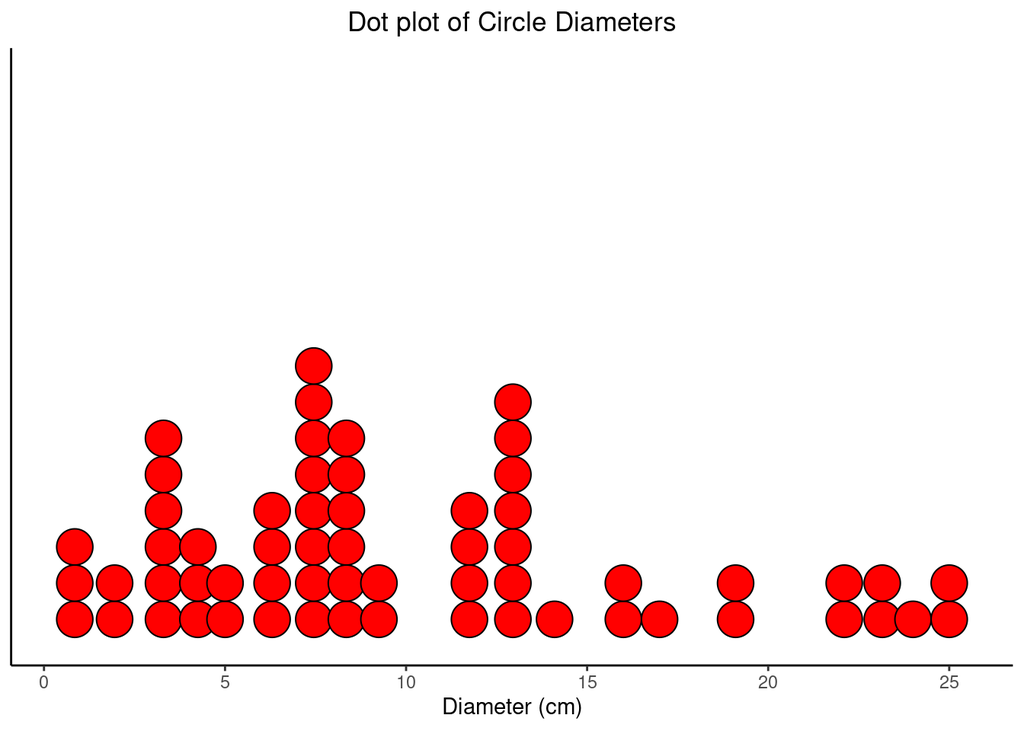

Now let’s look at the circumferences.

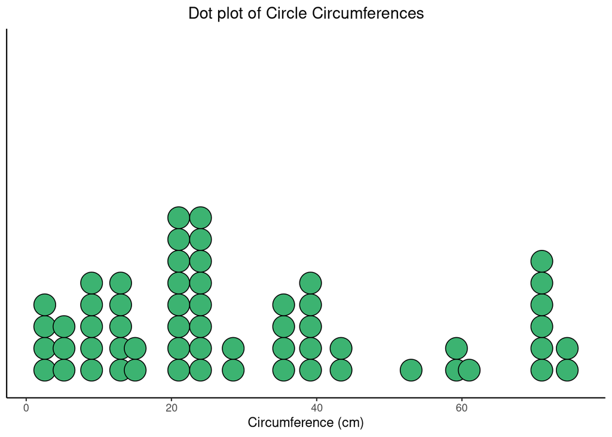

**Q: Does this dotplot look similar to the one for diameters?**

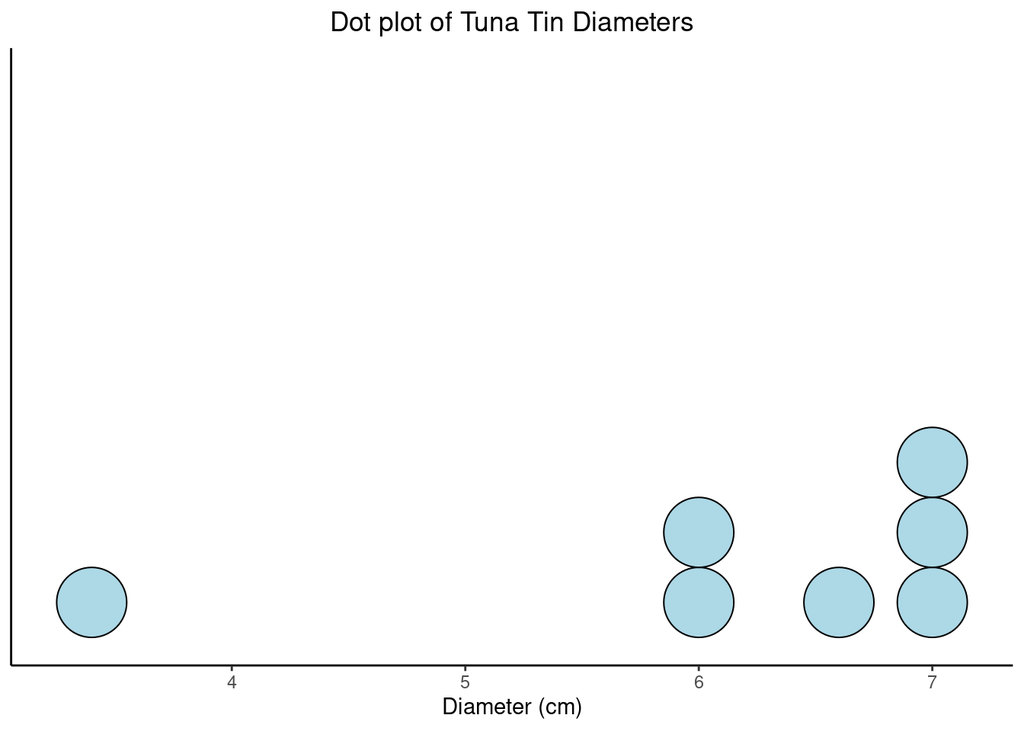

The last question on the form was about difficulty.

**Q: Which object do you think most groups found the hardest to measure?**

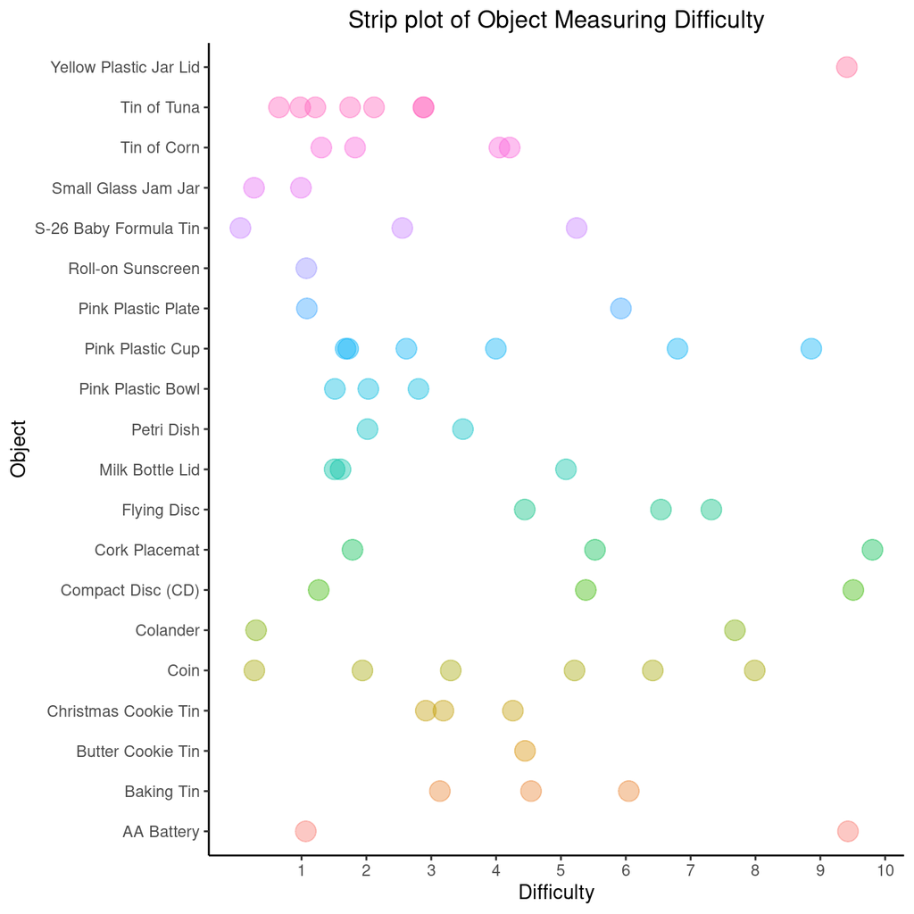

The very last plot will help us answer our hypothesis about whether we can tell the circumference of a circle if we know its diameter.

We’ll take a quick look now but talk more about it next time.

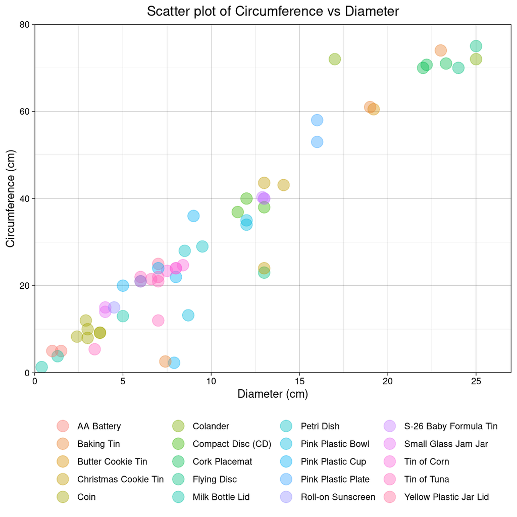

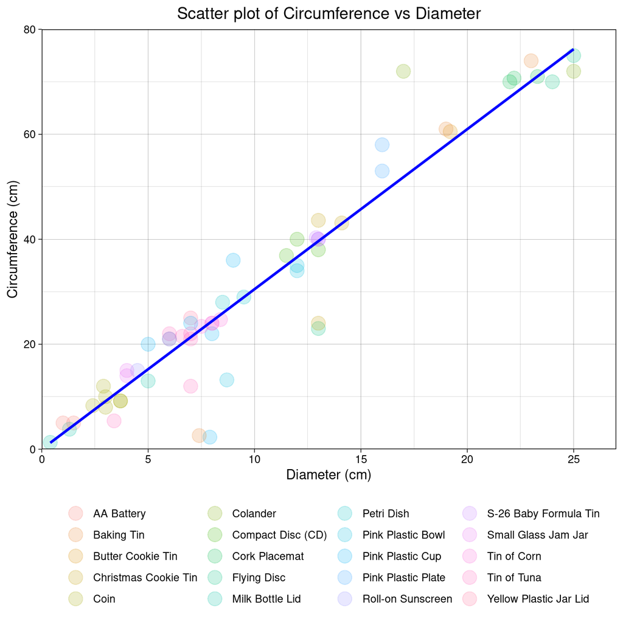

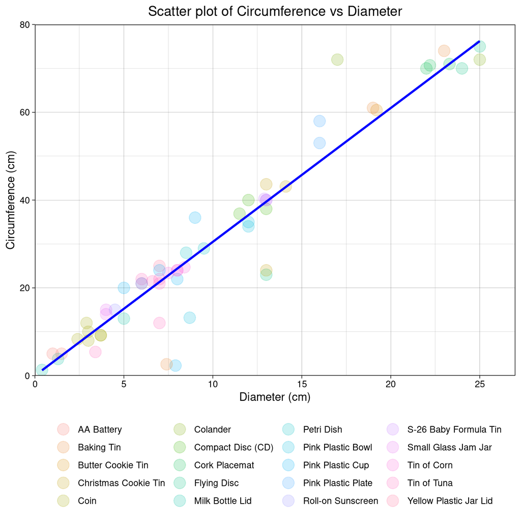

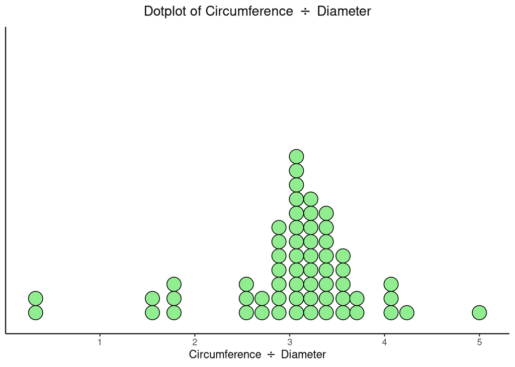

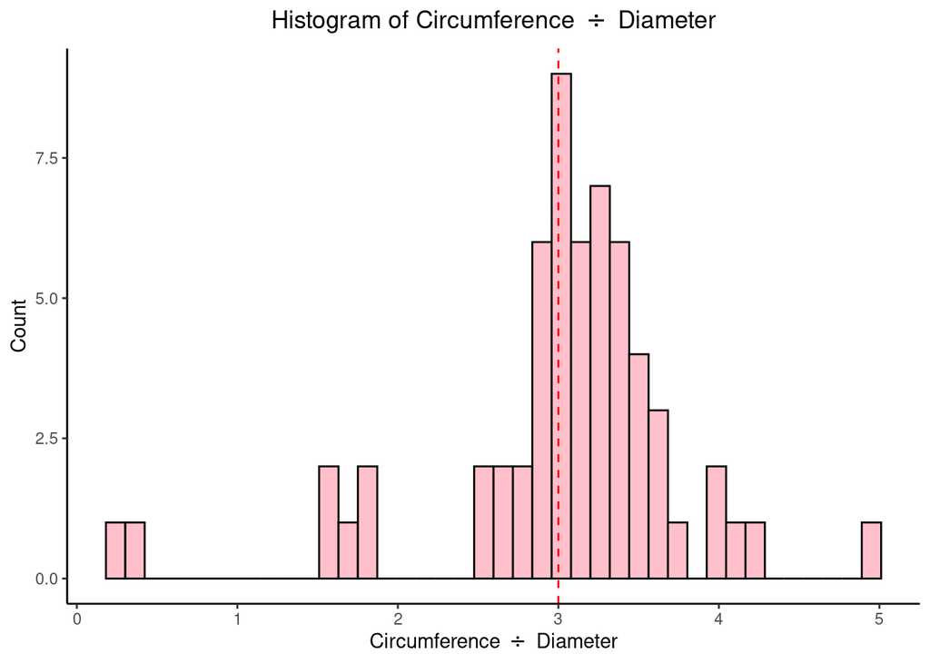

[figure not shown]

```
boundary (singular) fit: see help('isSingular')
```

```
Linear mixed model fit by REML. t-tests use Satterthwaite's method [
lmerModLmerTest]
Formula: Circumference ~ Diameter + (1 | Object)
   Data: circles_data

REML criterion at convergence: 394.6

Scaled residuals:
    Min      1Q  Median      3Q     Max
-3.2425 -0.1874  0.1820  0.4735  3.0456

Random effects:
 Groups   Name        Variance Std.Dev.
 Object   (Intercept)  0.00    0.000
 Residual             42.89    6.549
Number of obs: 60, groups:  Object, 20

Fixed effects:
            Estimate Std. Error      df t value Pr(>|t|)
(Intercept)  -1.2202     1.5422 58.0000  -0.791    0.432
Diameter      3.1337     0.1282 58.0000  24.439   <2e-16 ***
---
Signif. codes:  0 '***' 0.001 '**' 0.01 '*' 0.05 '.' 0.1 ' ' 1

Correlation of Fixed Effects:
         (Intr)
Diameter -0.836
optimizer (nloptwrap) convergence code: 0 (OK)
boundary (singular) fit: see help('isSingular')
```